# Optimal Treatment Analysis

## Outcome Variable

**Outcome Variable:** ever_stunted

## Predictor Variables

**Intervention Variable:** nhh

**Adjustment Set:**

- arm
- W_mage
- meducyrs
- feducyrs
- W_mhtcm
- W_mwtkg
- W_mbmi
- W_nrooms
- impfloor
- impsan
- safeh20
- delta_W_mage
- delta_meducyrs
- delta_feducyrs
- delta_W_mhtcm
- delta_W_mwtkg
- delta_W_mbmi
- delta_W_nrooms
- delta_impfloor
- delta_impsan
- delta_safeh20

## Stratifying Variables

The analysis was stratified on these variable(s):

- agecat
- studyid
- country

## Data Summary

| agecat | studyid | country | nhh | ever_stunted | n_cell | n |
| --- | --- | --- | --- | --- | --- | --- |
| 0-24 months | ki1000108-IRC | INDIA | 3 or less | 0 | 25 | 410 |
| 0-24 months | ki1000108-IRC | INDIA | 3 or less | 1 | 33 | 410 |
| 0-24 months | ki1000108-IRC | INDIA | 4-5 | 0 | 52 | 410 |
| 0-24 months | ki1000108-IRC | INDIA | 4-5 | 1 | 106 | 410 |
| 0-24 months | ki1000108-IRC | INDIA | 6-7 | 0 | 41 | 410 |
| 0-24 months | ki1000108-IRC | INDIA | 6-7 | 1 | 66 | 410 |
| 0-24 months | ki1000108-IRC | INDIA | 8+ | 0 | 29 | 410 |
| 0-24 months | ki1000108-IRC | INDIA | 8+ | 1 | 58 | 410 |
| 0-24 months | ki1000304b-SAS-FoodSuppl | INDIA | 3 or less | 0 | 9 | 418 |
| 0-24 months | ki1000304b-SAS-FoodSuppl | INDIA | 3 or less | 1 | 29 | 418 |
| 0-24 months | ki1000304b-SAS-FoodSuppl | INDIA | 4-5 | 0 | 35 | 418 |
| 0-24 months | ki1000304b-SAS-FoodSuppl | INDIA | 4-5 | 1 | 148 | 418 |
| 0-24 months | ki1000304b-SAS-FoodSuppl | INDIA | 6-7 | 0 | 16 | 418 |
| 0-24 months | ki1000304b-SAS-FoodSuppl | INDIA | 6-7 | 1 | 111 | 418 |
| 0-24 months | ki1000304b-SAS-FoodSuppl | INDIA | 8+ | 0 | 12 | 418 |
| 0-24 months | ki1000304b-SAS-FoodSuppl | INDIA | 8+ | 1 | 58 | 418 |
| 0-24 months | ki1017093-NIH-Birth | BANGLADESH | 3 or less | 0 | 47 | 629 |
| 0-24 months | ki1017093-NIH-Birth | BANGLADESH | 3 or less | 1 | 70 | 629 |
| 0-24 months | ki1017093-NIH-Birth | BANGLADESH | 4-5 | 0 | 77 | 629 |
| 0-24 months | ki1017093-NIH-Birth | BANGLADESH | 4-5 | 1 | 187 | 629 |
| 0-24 months | ki1017093-NIH-Birth | BANGLADESH | 6-7 | 0 | 42 | 629 |
| 0-24 months | ki1017093-NIH-Birth | BANGLADESH | 6-7 | 1 | 100 | 629 |
| 0-24 months | ki1017093-NIH-Birth | BANGLADESH | 8+ | 0 | 45 | 629 |
| 0-24 months | ki1017093-NIH-Birth | BANGLADESH | 8+ | 1 | 61 | 629 |
| 0-24 months | ki1017093b-PROVIDE | BANGLADESH | 3 or less | 0 | 83 | 700 |
| 0-24 months | ki1017093b-PROVIDE | BANGLADESH | 3 or less | 1 | 57 | 700 |
| 0-24 months | ki1017093b-PROVIDE | BANGLADESH | 4-5 | 0 | 179 | 700 |
| 0-24 months | ki1017093b-PROVIDE | BANGLADESH | 4-5 | 1 | 143 | 700 |
| 0-24 months | ki1017093b-PROVIDE | BANGLADESH | 6-7 | 0 | 84 | 700 |
| 0-24 months | ki1017093b-PROVIDE | BANGLADESH | 6-7 | 1 | 67 | 700 |

[output cut: 114 more lines]

The following strata were considered:

- agecat: 0-24 months, studyid: ki1000108-IRC, country: INDIA
- agecat: 0-24 months, studyid: ki1000304b-SAS-FoodSuppl, country: INDIA
- agecat: 0-24 months, studyid: ki1017093-NIH-Birth, country: BANGLADESH
- agecat: 0-24 months, studyid: ki1017093b-PROVIDE, country: BANGLADESH
- agecat: 0-24 months, studyid: ki1017093c-NIH-Crypto, country: BANGLADESH
- agecat: 0-24 months, studyid: ki1148112-LCNI-5, country: MALAWI
- agecat: 0-6 months, studyid: ki1000108-IRC, country: INDIA
- agecat: 0-6 months, studyid: ki1000304b-SAS-FoodSuppl, country: INDIA
- agecat: 0-6 months, studyid: ki1017093-NIH-Birth, country: BANGLADESH
- agecat: 0-6 months, studyid: ki1017093b-PROVIDE, country: BANGLADESH
- agecat: 0-6 months, studyid: ki1017093c-NIH-Crypto, country: BANGLADESH
- agecat: 0-6 months, studyid: ki1148112-LCNI-5, country: MALAWI
- agecat: 6-24 months, studyid: ki1000108-IRC, country: INDIA
- agecat: 6-24 months, studyid: ki1000304b-SAS-FoodSuppl, country: INDIA
- agecat: 6-24 months, studyid: ki1017093-NIH-Birth, country: BANGLADESH
- agecat: 6-24 months, studyid: ki1017093b-PROVIDE, country: BANGLADESH
- agecat: 6-24 months, studyid: ki1017093c-NIH-Crypto, country: BANGLADESH
- agecat: 6-24 months, studyid: ki1148112-LCNI-5, country: MALAWI

### Dropped Strata

Some strata were dropped due to rare outcomes:

- agecat: 0-6 months, studyid: ki1148112-LCNI-5, country: MALAWI

## Methods Detail

We’re interested in the causal parameters $E[Y_a]$ for all values of $a \in \mathcal{A}$. These parameters represent the mean outcome if, possibly contrary to fact, we intervened to set all units to have $A=a$. Under the randomization and positivity assumptions, these are identified by the statistical parameters $\psi_a=E_W[E_{Y|A,W}(Y|A=a,W)]$. In addition, we’re interested in the mean of $Y$, $E[Y]$ under no intervention (the observed mean). We will estimate these parameters by using SuperLearner to fit the relevant likelihood factors – $E_{Y|A,W}(Y|A=a,W)$ and $p(A=a|W)$, and then updating our likelihood fit using a joint TMLE.

For unadjusted analyses ($W=\{\}$), initial likelihoods were estimated using Lrnr_glm to estimate the simple $E(Y|A)$ and Lrnr_mean to estimate $p(A)$. For adjusted analyses, a small library containing Lrnr_glmnet, Lrnr_xgboost, and Lrnr_mean was used.

Having estimated these parameters, we will then use the delta method to estimate relative risks and attributable risks relative to a prespecified baseline level of $A$.

# Results Detail

## Results Plots

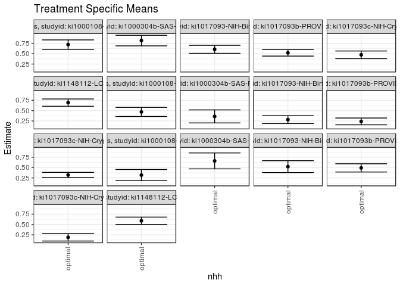

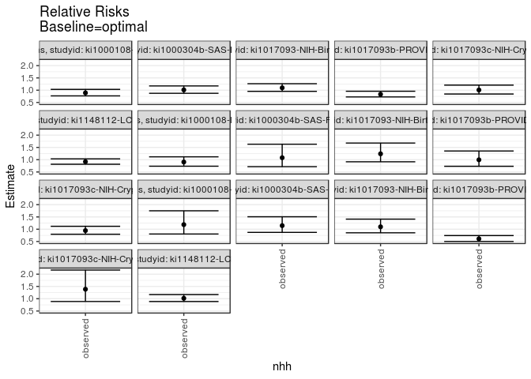

## Results Table

### Parameter: TSM

| agecat | studyid | country | intervention_level | baseline_level | estimate | ci_lower | ci_upper |
| --- | --- | --- | --- | --- | --- | --- | --- |
| 0-24 months | ki1000108-IRC | INDIA | optimal | NA | 0.7206535 | 0.6069220 | 0.8343849 |
| 0-24 months | ki1000304b-SAS-FoodSuppl | INDIA | optimal | NA | 0.8178597 | 0.6902974 | 0.9454220 |
| 0-24 months | ki1017093-NIH-Birth | BANGLADESH | optimal | NA | 0.6060155 | 0.5093560 | 0.7026750 |
| 0-24 months | ki1017093b-PROVIDE | BANGLADESH | optimal | NA | 0.5211255 | 0.4427131 | 0.5995378 |
| 0-24 months | ki1017093c-NIH-Crypto | BANGLADESH | optimal | NA | 0.4733082 | 0.3809261 | 0.5656904 |
| 0-24 months | ki1148112-LCNI-5 | MALAWI | optimal | NA | 0.6941641 | 0.6057663 | 0.7825619 |
| 0-6 months | ki1000108-IRC | INDIA | optimal | NA | 0.4687401 | 0.3588415 | 0.5786387 |
| 0-6 months | ki1000304b-SAS-FoodSuppl | INDIA | optimal | NA | 0.3603374 | 0.2030072 | 0.5176675 |
| 0-6 months | ki1017093-NIH-Birth | BANGLADESH | optimal | NA | 0.2822031 | 0.1877056 | 0.3767006 |
| 0-6 months | ki1017093b-PROVIDE | BANGLADESH | optimal | NA | 0.2396389 | 0.1574724 | 0.3218053 |
| 0-6 months | ki1017093c-NIH-Crypto | BANGLADESH | optimal | NA | 0.3202663 | 0.2565077 | 0.3840250 |
| 6-24 months | ki1000108-IRC | INDIA | optimal | NA | 0.3177861 | 0.1819633 | 0.4536090 |
| 6-24 months | ki1000304b-SAS-FoodSuppl | INDIA | optimal | NA | 0.6608344 | 0.4682487 | 0.8534201 |
| 6-24 months | ki1017093-NIH-Birth | BANGLADESH | optimal | NA | 0.5228034 | 0.3792205 | 0.6663863 |
| 6-24 months | ki1017093b-PROVIDE | BANGLADESH | optimal | NA | 0.4922685 | 0.3922528 | 0.5922841 |
| 6-24 months | ki1017093c-NIH-Crypto | BANGLADESH | optimal | NA | 0.1895934 | 0.1002263 | 0.2789605 |
| 6-24 months | ki1148112-LCNI-5 | MALAWI | optimal | NA | 0.5894095 | 0.5003239 | 0.6784952 |

### Parameter: E(Y)

| agecat | studyid | country | intervention_level | baseline_level | estimate | ci_lower | ci_upper |
| --- | --- | --- | --- | --- | --- | --- | --- |
| 0-24 months | ki1000108-IRC | INDIA | observed | NA | 0.6414634 | 0.5949863 | 0.6879405 |
| 0-24 months | ki1000304b-SAS-FoodSuppl | INDIA | observed | NA | 0.8277512 | 0.7915095 | 0.8639929 |
| 0-24 months | ki1017093-NIH-Birth | BANGLADESH | observed | NA | 0.6645469 | 0.6276196 | 0.7014742 |
| 0-24 months | ki1017093b-PROVIDE | BANGLADESH | observed | NA | 0.4342857 | 0.3975409 | 0.4710305 |
| 0-24 months | ki1017093c-NIH-Crypto | BANGLADESH | observed | NA | 0.4775726 | 0.4419904 | 0.5131548 |
| 0-24 months | ki1148112-LCNI-5 | MALAWI | observed | NA | 0.6376989 | 0.6047193 | 0.6706785 |
| 0-6 months | ki1000108-IRC | INDIA | observed | NA | 0.4243902 | 0.3764905 | 0.4722900 |
| 0-6 months | ki1000304b-SAS-FoodSuppl | INDIA | observed | NA | 0.3894231 | 0.3425088 | 0.4363374 |
| 0-6 months | ki1017093-NIH-Birth | BANGLADESH | observed | NA | 0.3497615 | 0.3124631 | 0.3870600 |
| 0-6 months | ki1017093b-PROVIDE | BANGLADESH | observed | NA | 0.2385714 | 0.2069753 | 0.2701675 |
| 0-6 months | ki1017093c-NIH-Crypto | BANGLADESH | observed | NA | 0.3021108 | 0.2694011 | 0.3348205 |
| 6-24 months | ki1000108-IRC | INDIA | observed | NA | 0.3771186 | 0.3151523 | 0.4390850 |
| 6-24 months | ki1000304b-SAS-FoodSuppl | INDIA | observed | NA | 0.7572016 | 0.7031798 | 0.8112234 |
| 6-24 months | ki1017093-NIH-Birth | BANGLADESH | observed | NA | 0.5739130 | 0.5216565 | 0.6261696 |
| 6-24 months | ki1017093b-PROVIDE | BANGLADESH | observed | NA | 0.2997812 | 0.2577294 | 0.3418330 |
| 6-24 months | ki1017093c-NIH-Crypto | BANGLADESH | observed | NA | 0.2628458 | 0.2244546 | 0.3012371 |
| 6-24 months | ki1148112-LCNI-5 | MALAWI | observed | NA | 0.6000000 | 0.5639396 | 0.6360604 |

### Parameter: RR

| agecat | studyid | country | intervention_level | baseline_level | estimate | ci_lower | ci_upper |
| --- | --- | --- | --- | --- | --- | --- | --- |
| 0-24 months | ki1000108-IRC | INDIA | observed | optimal | 0.8901136 | 0.7673694 | 1.0324912 |
| 0-24 months | ki1000304b-SAS-FoodSuppl | INDIA | observed | optimal | 1.0120943 | 0.8728671 | 1.1735291 |
| 0-24 months | ki1017093-NIH-Birth | BANGLADESH | observed | optimal | 1.0965840 | 0.9519567 | 1.2631839 |
| 0-24 months | ki1017093b-PROVIDE | BANGLADESH | observed | optimal | 0.8333612 | 0.7255098 | 0.9572452 |
| 0-24 months | ki1017093c-NIH-Crypto | BANGLADESH | observed | optimal | 1.0090096 | 0.8439818 | 1.2063061 |
| 0-24 months | ki1148112-LCNI-5 | MALAWI | observed | optimal | 0.9186573 | 0.8151192 | 1.0353470 |
| 0-6 months | ki1000108-IRC | INDIA | observed | optimal | 0.9053850 | 0.7343328 | 1.1162814 |
| 0-6 months | ki1000304b-SAS-FoodSuppl | INDIA | observed | optimal | 1.0807180 | 0.7159540 | 1.6313218 |
| 0-6 months | ki1017093-NIH-Birth | BANGLADESH | observed | optimal | 1.2393964 | 0.9150241 | 1.6787572 |
| 0-6 months | ki1017093b-PROVIDE | BANGLADESH | observed | optimal | 0.9955456 | 0.7314148 | 1.3550604 |
| 0-6 months | ki1017093c-NIH-Crypto | BANGLADESH | observed | optimal | 0.9433111 | 0.7952737 | 1.1189052 |
| 6-24 months | ki1000108-IRC | INDIA | observed | optimal | 1.1867058 | 0.8046069 | 1.7502593 |
| 6-24 months | ki1000304b-SAS-FoodSuppl | INDIA | observed | optimal | 1.1458266 | 0.8712611 | 1.5069175 |
| 6-24 months | ki1017093-NIH-Birth | BANGLADESH | observed | optimal | 1.0977607 | 0.8545725 | 1.4101537 |
| 6-24 months | ki1017093b-PROVIDE | BANGLADESH | observed | optimal | 0.6089791 | 0.5002766 | 0.7413010 |
| 6-24 months | ki1017093c-NIH-Crypto | BANGLADESH | observed | optimal | 1.3863659 | 0.8866967 | 2.1676076 |
| 6-24 months | ki1148112-LCNI-5 | MALAWI | observed | optimal | 1.0179679 | 0.8863252 | 1.1691630 |

### Parameter: PAR

| agecat | studyid | country | intervention_level | baseline_level | estimate | ci_lower | ci_upper |
| --- | --- | --- | --- | --- | --- | --- | --- |
| 0-24 months | ki1000108-IRC | INDIA | optimal | NA | -0.0791900 | -0.1856442 | 0.0272641 |
| 0-24 months | ki1000304b-SAS-FoodSuppl | INDIA | optimal | NA | 0.0098915 | -0.1111305 | 0.1309134 |
| 0-24 months | ki1017093-NIH-Birth | BANGLADESH | optimal | NA | 0.0585314 | -0.0267555 | 0.1438183 |
| 0-24 months | ki1017093b-PROVIDE | BANGLADESH | optimal | NA | -0.0868397 | -0.1582657 | -0.0154138 |
| 0-24 months | ki1017093c-NIH-Crypto | BANGLADESH | optimal | NA | 0.0042643 | -0.0802584 | 0.0887870 |
| 0-24 months | ki1148112-LCNI-5 | MALAWI | optimal | NA | -0.0564652 | -0.1393450 | 0.0264146 |
| 0-6 months | ki1000108-IRC | INDIA | optimal | NA | -0.0443498 | -0.1424594 | 0.0537597 |
| 0-6 months | ki1000304b-SAS-FoodSuppl | INDIA | optimal | NA | 0.0290857 | -0.1190977 | 0.1772691 |
| 0-6 months | ki1017093-NIH-Birth | BANGLADESH | optimal | NA | 0.0675584 | -0.0174037 | 0.1525205 |
| 0-6 months | ki1017093b-PROVIDE | BANGLADESH | optimal | NA | -0.0010674 | -0.0749593 | 0.0728244 |
| 0-6 months | ki1017093c-NIH-Crypto | BANGLADESH | optimal | NA | -0.0181555 | -0.0727980 | 0.0364869 |
| 6-24 months | ki1000108-IRC | INDIA | optimal | NA | 0.0593325 | -0.0641814 | 0.1828464 |
| 6-24 months | ki1000304b-SAS-FoodSuppl | INDIA | optimal | NA | 0.0963672 | -0.0839470 | 0.2766815 |
| 6-24 months | ki1017093-NIH-Birth | BANGLADESH | optimal | NA | 0.0511096 | -0.0794449 | 0.1816642 |
| 6-24 months | ki1017093b-PROVIDE | BANGLADESH | optimal | NA | -0.1924873 | -0.2845809 | -0.1003937 |
| 6-24 months | ki1017093c-NIH-Crypto | BANGLADESH | optimal | NA | 0.0732524 | -0.0120678 | 0.1585727 |
| 6-24 months | ki1148112-LCNI-5 | MALAWI | optimal | NA | 0.0105905 | -0.0710311 | 0.0922121 |

### Parameter: PAF

| agecat | studyid | country | intervention_level | baseline_level | estimate | ci_lower | ci_upper |
| --- | --- | --- | --- | --- | --- | --- | --- |
| 0-24 months | ki1000108-IRC | INDIA | optimal | NA | -0.1234522 | -0.3031533 | 0.0314687 |
| 0-24 months | ki1000304b-SAS-FoodSuppl | INDIA | optimal | NA | 0.0119498 | -0.1456498 | 0.1478694 |
| 0-24 months | ki1017093-NIH-Birth | BANGLADESH | optimal | NA | 0.0880771 | -0.0504680 | 0.2083497 |
| 0-24 months | ki1017093b-PROVIDE | BANGLADESH | optimal | NA | -0.1999599 | -0.3783411 | -0.0446644 |
| 0-24 months | ki1017093c-NIH-Crypto | BANGLADESH | optimal | NA | 0.0089291 | -0.1848597 | 0.1710230 |
| 0-24 months | ki1148112-LCNI-5 | MALAWI | optimal | NA | -0.0885452 | -0.2268145 | 0.0341402 |
| 0-6 months | ki1000108-IRC | INDIA | optimal | NA | -0.1045025 | -0.3617804 | 0.1041685 |
| 0-6 months | ki1000304b-SAS-FoodSuppl | INDIA | optimal | NA | 0.0746892 | -0.3967377 | 0.3870002 |
| 0-6 months | ki1017093-NIH-Birth | BANGLADESH | optimal | NA | 0.1931556 | -0.0928674 | 0.4043213 |
| 0-6 months | ki1017093b-PROVIDE | BANGLADESH | optimal | NA | -0.0044743 | -0.3672133 | 0.2620255 |
| 0-6 months | ki1017093c-NIH-Crypto | BANGLADESH | optimal | NA | -0.0600956 | -0.2574287 | 0.1062692 |
| 6-24 months | ki1000108-IRC | INDIA | optimal | NA | 0.1573312 | -0.2428429 | 0.4286561 |
| 6-24 months | ki1000304b-SAS-FoodSuppl | INDIA | optimal | NA | 0.1272676 | -0.1477616 | 0.3363937 |
| 6-24 months | ki1017093-NIH-Birth | BANGLADESH | optimal | NA | 0.0890547 | -0.1701757 | 0.2908575 |
| 6-24 months | ki1017093b-PROVIDE | BANGLADESH | optimal | NA | -0.6420926 | -0.9988944 | -0.3489798 |
| 6-24 months | ki1017093c-NIH-Crypto | BANGLADESH | optimal | NA | 0.2786897 | -0.1277814 | 0.5386619 |
| 6-24 months | ki1148112-LCNI-5 | MALAWI | optimal | NA | 0.0176508 | -0.1282540 | 0.1446873 |